# Annual Fund $10K Model Data Exploration

# Goal

Clean up and explore the dataset generated with the `ksm-af-10k-data.sql` query with reusable R code.

# Setup

## Required packages

My code makes use of several packages:

```r
scan('PACKAGES.txt', what = 'character')
```

```
Read 7 items
```

```
[1] "devtools"  "wranglR"   "tidyverse" "lubridate" "gridExtra" "knitr"     "Boruta"
```

This code will install and load them as necessary. First, install `devtools` and my `wranglR` package:

```r
# Check to see if devtools is unavailable
if (!('devtools' %in% utils::installed.packages()[, 'Package'])) {
  # If unavailable, install it
  install.packages('devtools')
}
# Check to see if wranglR is unavailable
if (!('wranglR' %in% utils::installed.packages()[, 'Package'])) {
  # If unavailable, use devtools to install it via GitHub
  devtools::install_github('phively/wranglR')
}
```

## Load libraries

Now load `wranglR` and use it to install or load the other required packages:

```r
# Load wranglR
library(wranglR)
# Feed the libraries specified in PACKAGES.txt into wranglR's Libraries() function
Libraries(scan(file = 'PACKAGES.txt', what = 'character'))
```

```
Read 7 items
```

## Data preparation

```r
### Import the data
full.data <- read.csv('data/2017-12-21 AF 10K Model.csv', stringsAsFactors = FALSE, strip.white = TRUE,
                      colClasses = c('ID_NUMBER' = 'character'
                                     , 'HOUSEHOLD_ID' = 'character'
                                     , 'BIRTH_DT' = 'character'
                                     , 'ENTITY_DT_ADDED' = 'character'
                                     , 'GIVING_MAX_CASH_DT' = 'character'
                                     , 'GIVING_MAX_PLEDGE_DT' = 'character')) %>%
  # Drop any null rows
  filter(!is.na(RN)) %>%
  # Drop row numbers
  select(-RN)
### Clean the data
full.data <- full.data %>%
  # Convert NA to 0
  mutate_all(
    funs(
      ifelse(is.na(.), 0, .)
    )
  ) %>%
  # Convert to date
  mutate(
      DOB = ToDate(BIRTH_DT, method = 'ymd')
    , ENTITY_DT = ToDate(ENTITY_DT_ADDED, method = 'mdy')
    , GIVING_MAX_CASH_DT = ToDate(GIVING_MAX_CASH_DT, method = 'mdy')
    , GIVING_MAX_PLEDGE_DT = ToDate(GIVING_MAX_CASH_DT, method = 'mdy')
  ) %>%
  # Extract dates
  mutate(
      GIVING_MAX_CASH_YR = year(GIVING_MAX_CASH_DT)
    , GIVING_MAX_CASH_MO = month(GIVING_MAX_CASH_DT) %>% factor()
  ) %>%
  # Convert certain character to factor
  mutate(
    # Factors
      RECORD_STATUS_CODE = factor(RECORD_STATUS_CODE) %>% relevel(ref = 'A') # Active
    , HOUSEHOLD_RECORD = factor(HOUSEHOLD_RECORD) %>% relevel(ref = 'AL') # Alumni
    , PROGRAM_GROUP = factor(PROGRAM_GROUP) %>% relevel(ref = 'FT') # Full-Time
    , PREF_ADDR_TYPE_CODE = factor(PREF_ADDR_TYPE_CODE) %>% relevel(ref = 'H') # Home
    , HOUSEHOLD_STATE = factor(HOUSEHOLD_STATE) %>% relevel(ref = 'IL') # Illinois
    , HOUSEHOLD_COUNTRY = factor(HOUSEHOLD_COUNTRY) %>% relevel(ref = 'United States')
    , HOUSEHOLD_CONTINENT = factor(HOUSEHOLD_CONTINENT) %>% relevel(ref = 'North America')
    , EVALUATION_RATING = factor(EVALUATION_RATING) %>% relevel(ref = '') # Unrated
    # Indicators
    , BUS_IS_EMPLOYED = factor(BUS_IS_EMPLOYED == 'Y')
    , BUS_HIGH_LVL_JOB_TITLE = factor(BUS_HIGH_LVL_JOB_TITLE != '')
    , BUS_CAREER_SPEC_FINANCE = factor(BUS_CAREER_SPEC_FINANCE != '')
    , BUS_GIFT_MATCH = factor(BUS_GIFT_MATCH == 'Y')
    , HAS_HOME_ADDR = factor(HAS_HOME_ADDR == 'Y')
    , HAS_ALT_HOME_ADDR = factor(HAS_ALT_HOME_ADDR == 'Y')
    , HAS_BUS_ADDR = factor(HAS_BUS_ADDR == 'Y')
    , HAS_SEASONAL_ADDR = factor(HAS_SEASONAL_ADDR == 'Y')
    , HAS_HOME_PHONE = factor(HAS_HOME_PHONE == 'Y')
    , HAS_BUS_PHONE = factor(HAS_BUS_PHONE == 'Y')
    , HAS_MOBILE_PHONE = factor(HAS_MOBILE_PHONE == 'Y')
    , HAS_HOME_EMAIL = factor(HAS_HOME_EMAIL == 'Y')
    , HAS_BUS_EMAIL = factor(HAS_BUS_EMAIL == 'Y')
    , KSM_PROSPECT_ACTIVE = factor(KSM_PROSPECT_ACTIVE == 'Y')
    , KSM_PROSPECT_ANY = factor(KSM_PROSPECT_ANY == 'Y')
  )
```

```
 27237 failed to parse.All formats failed to parse. No formats found.
```

“Failed to parse” means `DOB` is NA due to invalid `BIRTH_DT` format.

# Data Exploration

## Diagnostics

**Observations** from `summary(full.data)`

- Need to be cautious about the inserted 0s; e.g. discretize years?
- Should gift amounts be inflation-indexed? (CPI-U adjustment)
- DOB missing and impossible values: impute?

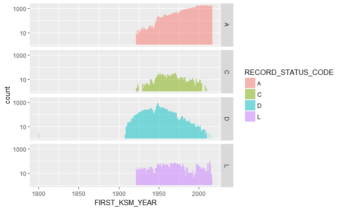

```r
full.data %>% filter(FIRST_KSM_YEAR != 0) %>%
  ggplot(aes(x = FIRST_KSM_YEAR, fill = RECORD_STATUS_CODE)) + geom_histogram(alpha = .5, binwidth = 1) +
  facet_grid(RECORD_STATUS_CODE ~ .) + scale_y_log10()
```

- Check 1800 grad year

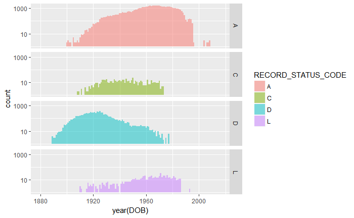

```r
full.data %>% filter(!is.na(DOB) & year(DOB) != 0) %>%
  ggplot(aes(x = year(DOB), fill = RECORD_STATUS_CODE)) + geom_histogram(alpha = .5, binwidth = 1) +
  facet_grid(RECORD_STATUS_CODE ~ .) + scale_y_log10()
```

- Check the person with DOB year 0
- Check people with DOB after 2000…or in general after they graduated?

## Inflation adjustment exploration

Plot largest nominal cash gift from each donor against the year in which it was made.

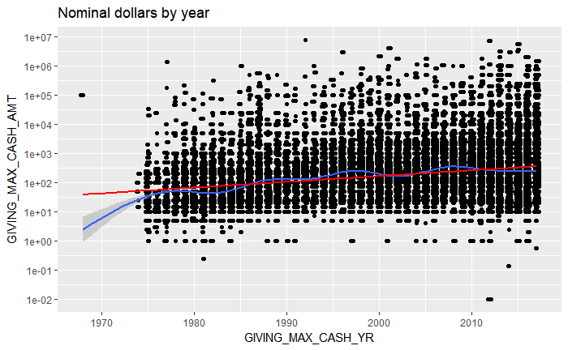

```r
full.data %>% filter(GIVING_MAX_CASH_AMT > 0) %>%
  ggplot(aes(x = GIVING_MAX_CASH_YR, y = GIVING_MAX_CASH_AMT)) +
  geom_point() + geom_jitter(width = .25, height = 0) +
  scale_y_log10(breaks = 10^(-2:7)) + geom_smooth() +
   # Red line is linear trend
  geom_smooth(method = 'lm', color = 'red') +
  labs(title = "Nominal dollars by year")
```

Slight upward slope over the last 30-40 years.

```r
# Load historical CPI-U data
cpi.u <- read.csv('data/CPI 2017-09-01.csv', strip.white = TRUE) %>%
  mutate(
    AS_OF = mdy(AS_OF)
    , YEAR = CALENDAR_YEAR
  )
cpi.max <- cpi.u %>% filter(CALENDAR_YEAR == max(CALENDAR_YEAR)) %>% select(CPI_U_AVG) %>% as.numeric()
```

Plot largest inflation-adjusted cash gift (Sept 2017 dollars) from each donor against the year in which it was made.

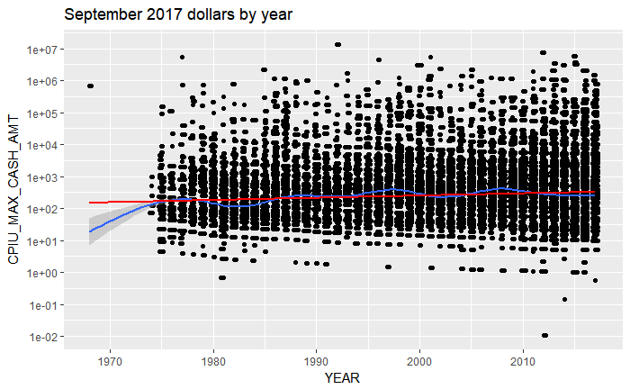

```r
full.data %>% filter(GIVING_MAX_CASH_AMT > 0) %>%
  # Join CPI-U columns
  mutate(YEAR = GIVING_MAX_CASH_YR) %>%
  inner_join(cpi.u, by = c('YEAR')) %>%
  # Compute inflation-adjusted amount
  mutate(CPIU_MAX_CASH_AMT = GIVING_MAX_CASH_AMT * cpi.max/CPI_U_AVG) %>%
  # Plot results
  ggplot(aes(x = YEAR, y = CPIU_MAX_CASH_AMT)) +
  geom_point() + geom_jitter(width = .25, height = 0) +
  scale_y_log10(breaks = 10^(-2:7)) + geom_smooth() +
  # Red line is linear trend
  geom_smooth(method = 'lm', color = 'red') +
  labs(title = "September 2017 dollars by year")
```

Inflation-adjusted there’s still a slight upward slope over time. Does look remarkably consistent over time.

## Response variable transformations

For Annual Giving, largest single cash gift is the logical response variable.

```r
summary2 <- function(x) {
  summary(x) %>% c(
    StDev = sd(x)
    , Skewnewss = e1071::skewness(x)
    , Kurtosis = e1071::kurtosis(x)
  ) %>% signif(digits = 3)
}
```

```r
full.data$GIVING_MAX_CASH_AMT %>% summary2()
```

```
     Min.   1st Qu.    Median      Mean   3rd Qu.      Max.     StDev Skewnewss  Kurtosis
 0.00e+00  0.00e+00  1.00e+01  2.86e+03  1.50e+02  7.84e+06  7.41e+04  6.27e+01  5.08e+03
```

```r
# Log10 transformation, no 0
{full.data %>% filter(GIVING_MAX_CASH_AMT > 0)}$GIVING_MAX_CASH_AMT %>% log10() %>% summary2()
```

```
     Min.   1st Qu.    Median      Mean   3rd Qu.      Max.     StDev Skewnewss  Kurtosis
   -2.000     1.700     2.180     2.250     2.700     6.900     0.775     0.897     2.210
```

```r
# Log10 transformation, with 0
{full.data$GIVING_MAX_CASH_AMT + 1} %>% log10() %>% summary2()
```

```
     Min.   1st Qu.    Median      Mean   3rd Qu.      Max.     StDev Skewnewss  Kurtosis
    0.000     0.000     1.040     1.160     2.180     6.900     1.260     0.578    -0.697
```

Giving is left-truncated at 0. I’d previously looked into alternate distributions with different datasets but the additional complexity was not worth it.

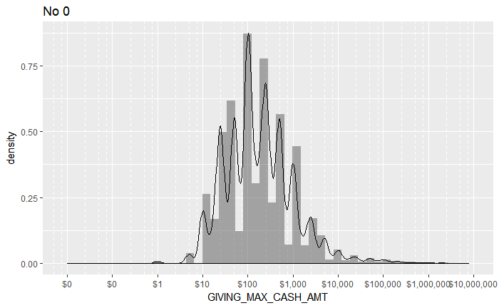

```r
# Density histogram
full.data %>% filter(GIVING_MAX_CASH_AMT > 0) %>%
  ggplot(aes(x = GIVING_MAX_CASH_AMT)) +
  geom_histogram(aes(y = ..density..), bins = 50, alpha = .5) +
  geom_density() +
  scale_x_log10(breaks = 10^(-2:7),
                minor_breaks = c(.25 * 10^(-2:7), .5 * 10^(-2:7), .75 * 10^(-2:7)),
                labels = scales::dollar) +
  theme(panel.grid.minor.x = element_line(linetype = 'dashed')) +
  labs(title = 'No 0')
```

Log scale appears to be a decent choice, though it’s still right-skewed.

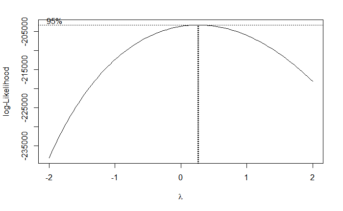

```r
# Box-Cox analysis
bc <- lm(log10(GIVING_MAX_CASH_AMT) ~ GIVING_MAX_CASH_YR, data = full.data %>% filter(GIVING_MAX_CASH_AMT > 1)) %>%
  MASS::boxcox()
```

```r
bc$x[which(bc$y == max(bc$y))]
```

```
[1] 0.2626263
```

According to this the best transformation on the 1-variable model is approximately $\sqrt[4]{\log(x)}$, which is quite hard to interpret. Log transformation is likely sufficient and has a reasonable explanation (error term $\epsilon$ enters multiplicatively).

## Response variable correlations

### Functions

```r
# ggplot2 boxplotting function from colname
boxplotter <- function(cname, data = full.data) {
  data %>% select(GIVING_MAX_CASH_AMT) %>% cbind(x = data[, cname]) %>%
    filter(GIVING_MAX_CASH_AMT > 0) %>%
    ggplot(aes(x = x, y = GIVING_MAX_CASH_AMT)) +
    geom_boxplot(alpha = .6) +
    scale_y_log10(breaks = 10^(-2:7), labels = scales::dollar) +
    labs(x = cname)
}
# ggplot2 scatterplotting function from colname
scatterplotter <- function(cname, data = full.data) {
  data %>% select(GIVING_MAX_CASH_AMT) %>% cbind(x = data[, cname]) %>%
    filter(GIVING_MAX_CASH_AMT > 0) %>%
    ggplot(aes(x = x, y = GIVING_MAX_CASH_AMT)) +
    geom_point(alpha = .6) +
    geom_smooth() +
    geom_smooth(method = 'lm', color = 'red') +
    scale_y_log10(breaks = 10^(-2:7), labels = scales::dollar) +
    labs(x = cname)
}
# ggplot2 histogram function from colname
histogrammer <- function(cname, m = 30, data = full.data) {
  data %>% cbind(x = data[, cname]) %>%
    ggplot(aes(x = x)) +
    geom_histogram(alpha = .6, bins = m) +
    geom_density(aes(y = ..count..)) +
    labs(x = cname)
}
```

### Categorical variables

```r
summary(full.data$RECORD_STATUS_CODE)
```

```
    A     C     D     L
71515  1259 16198  4255
```

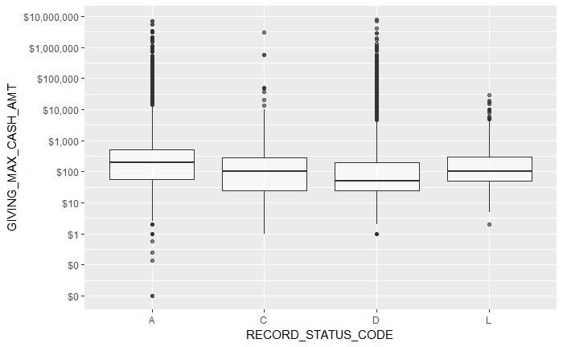

```r
boxplotter('RECORD_STATUS_CODE')
```

Good number within each factor and a meaningful indicator.

```r
summary(full.data$HOUSEHOLD_RECORD)
```

```
   AL     0    ST
88466  4737    24
```

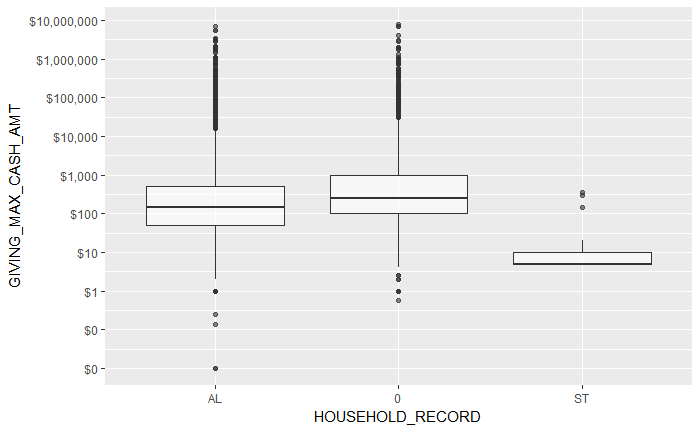

```r
boxplotter('HOUSEHOLD_RECORD')
```

Only a few students; good number of nonalumni. **Consider combining AL and ST**

```r
summary(full.data$HH_PRIMARY %>% as.factor())
```

```
    N     Y
 6993 86234
```

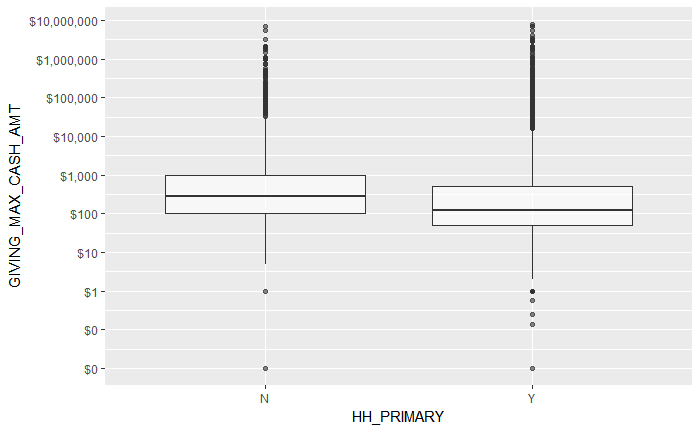

```r
boxplotter('HH_PRIMARY')
```

Should not include `N` in analysis as it duplicates a `Y` elsewhere in the file. **EXCLUDE**

```r
summary(full.data$PROGRAM_GROUP)
```

```
    FT           EMP EXECED NONGRD    PHD    TMP    UNK
 47137  11238  10689   7724   1754    786  13879     20
```

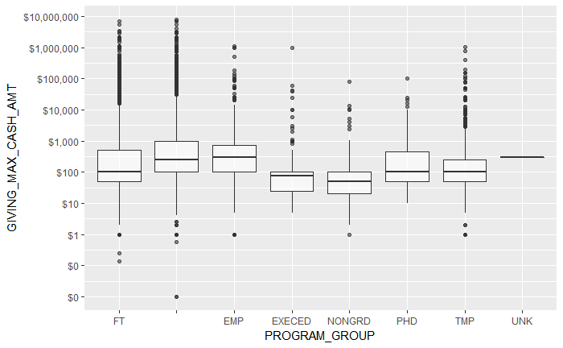

```r
boxplotter('PROGRAM_GROUP')
```

Only 20 UNK; others have a good number of rows. **Consider dropping UNK or treating as nonalum**

```r
summary(full.data$PREF_ADDR_TYPE_CODE)
```

```
    H     A    AB    AH     B     C     P     R     S    UB    UH    UX     X     Z
82228   613    40   596  9416     2     1    17    14    48   247     3     1     1
```

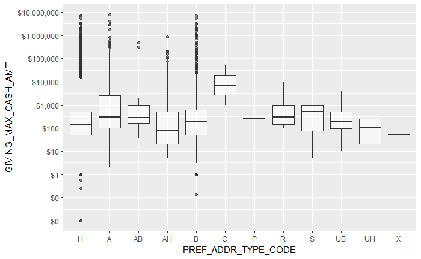

```r
boxplotter('PREF_ADDR_TYPE_CODE')
```

Several with very few examples; a few options here. Could combine all the Home-like and Business-like, and leave an Other for seasonal etc. Could also roll all the < 500, say, into an Other. **Consider combining categories**

```r
summary(full.data$HOUSEHOLD_STATE)
```

```
   IL          AB   ACT    AE    AK    AL    AP    AR    AZ    BC    CA    CO    CT    DC    DE
22614 30820    58     1     6    17    95     7   101   867    74  7109  1196   989   323    82
   FL    GA    HI    IA    ID    IN    KS    KY    LA    MA    MB    MD    ME    MI    MN    MO
 2873  1165   113   303    83   852   230   194    94  1632     4   682    79  1235  1204   604
   MP    MS    MT    NB    NC    ND    NE    NH    NJ    NL    NM    NS   NSW    NV    NY    OH
    1    36    54     3   988    14   125   129  1345     4   113     6   104   198  2843  1295
   OK    ON    OR    PA    PR    QC   QLD    RI    SA    SC    SD    SK   TAS    TN    TX    UT
  124   755   389  1135    30    69     7    75     3   294    30     3     1   484  2608   286
   VA    VI   VIC    VT    WA   WAU    WI    WV    WY
 1020     3    48    67  1260     8  1504    22    38
```

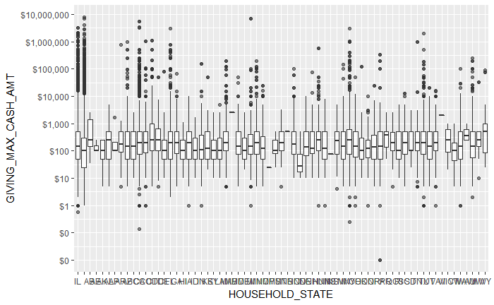

```r
boxplotter('HOUSEHOLD_STATE')
```

This appears to include Canadian and Australian states. Could also combine some of the lower-population areas. **Consider combining, perhaps based on region**

```r
summary(full.data$HOUSEHOLD_CONTINENT)
```

```
North America                      Africa          Asia        Europe       Oceania
        62804         21330           195          4469          3056           226
South America
         1147
```

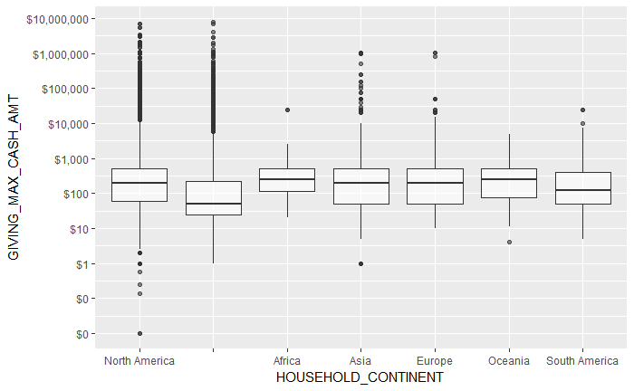

```r
boxplotter('HOUSEHOLD_CONTINENT')
```

Clear difference between those with and without an address; probably fine to include in model to suss out other differences.

```r
summary(full.data$BUS_IS_EMPLOYED)
```

```
FALSE  TRUE
41208 52019
```

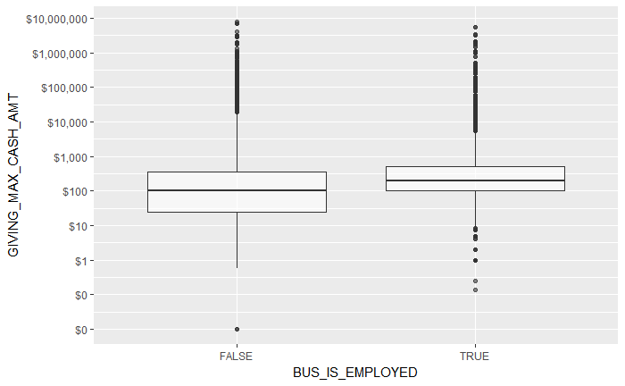

```r
boxplotter('BUS_IS_EMPLOYED')
```

Looks fine.

```r
summary(full.data$BUS_HIGH_LVL_JOB_TITLE)
```

```
FALSE  TRUE
76367 16860
```

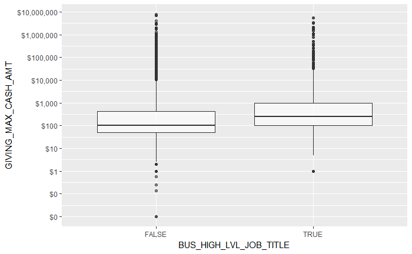

```r
boxplotter('BUS_HIGH_LVL_JOB_TITLE')
```

Looks fine.

```r
summary(full.data$BUS_CAREER_SPEC_FINANCE)
```

```
FALSE  TRUE
89017  4210
```

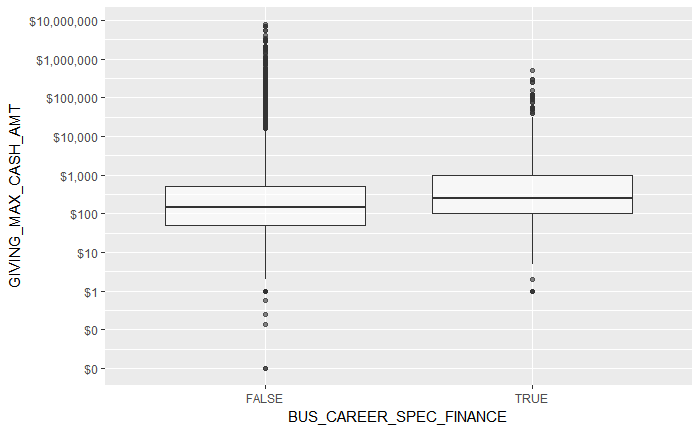

```r
boxplotter('BUS_CAREER_SPEC_FINANCE')
```

Looks fine.

```r
summary(full.data$BUS_GIFT_MATCH)
```

```
FALSE  TRUE
93119   108
```

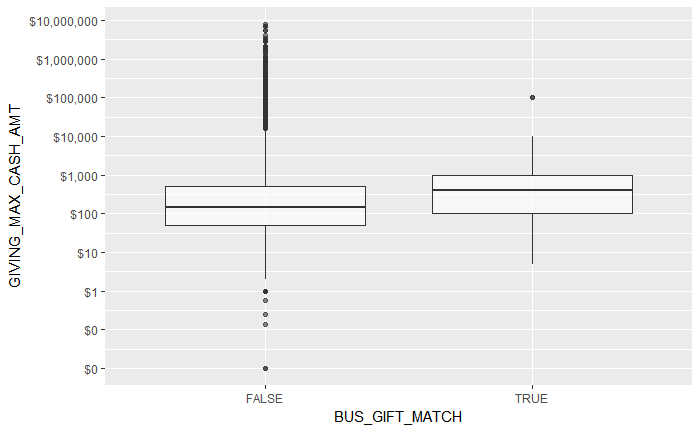

```r
boxplotter('BUS_GIFT_MATCH')
```

Very few that have matching companies; apparently this is not tracked consistently? **EXCLUDE**

```r
summary(full.data$HAS_HOME_ADDR)
```

```
FALSE  TRUE
23805 69422
```

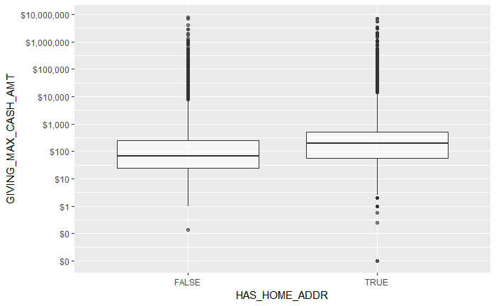

```r
boxplotter('HAS_HOME_ADDR')
```

Looks fine.

```r
summary(full.data$HAS_ALT_HOME_ADDR)
```

```
FALSE  TRUE
86370  6857
```

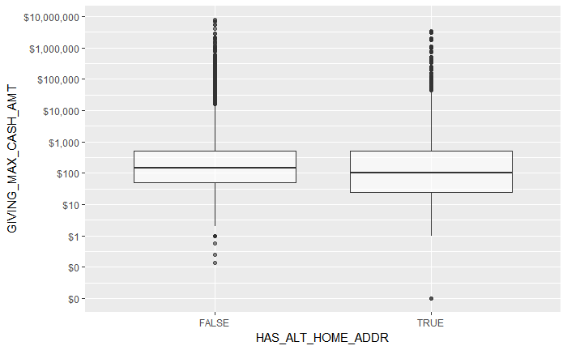

```r
boxplotter('HAS_ALT_HOME_ADDR')
```

Looks fine.

```r
summary(full.data$HAS_BUS_ADDR)
```

```
FALSE  TRUE
52114 41113
```

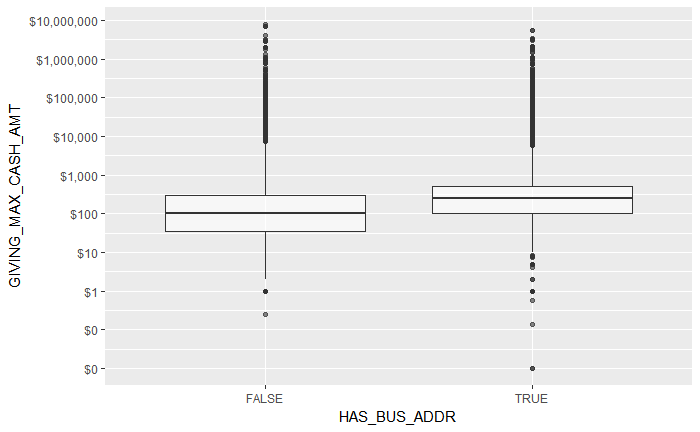

```r
boxplotter('HAS_BUS_ADDR')
```

Looks fine.

```r
summary(full.data$HAS_SEASONAL_ADDR)
```

```
FALSE  TRUE
92865   362
```

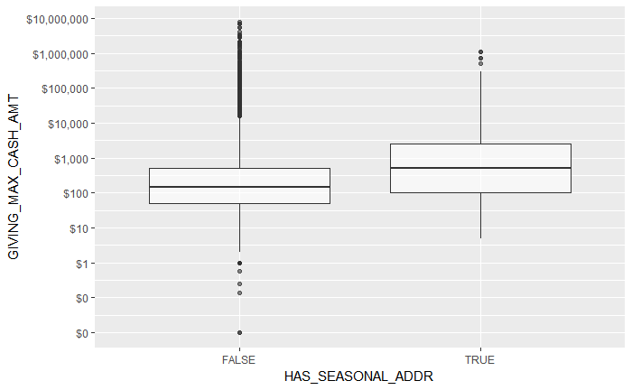

```r
boxplotter('HAS_SEASONAL_ADDR')
```

Low count. **Consider combining with alternate home address**

```r
summary(full.data$HAS_HOME_PHONE)
```

```
FALSE  TRUE
33928 59299
```

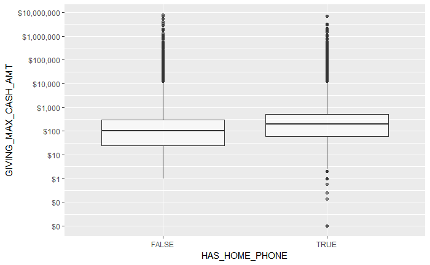

```r
boxplotter('HAS_HOME_PHONE')
```

Looks fine.

```r
summary(full.data$HAS_BUS_PHONE)
```

```
FALSE  TRUE
61703 31524
```

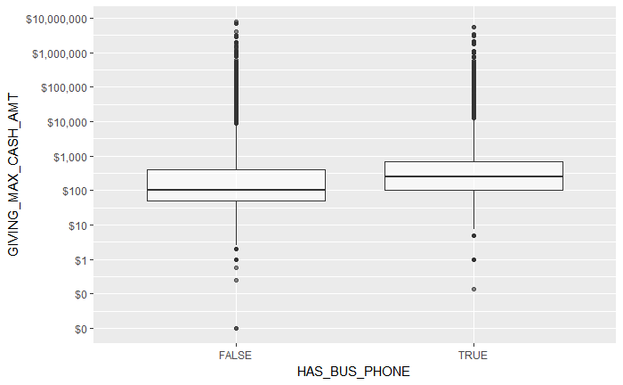

```r
boxplotter('HAS_BUS_PHONE')
```

Looks fine.

```r
summary(full.data$HAS_MOBILE_PHONE)
```

```
FALSE  TRUE
67879 25348
```

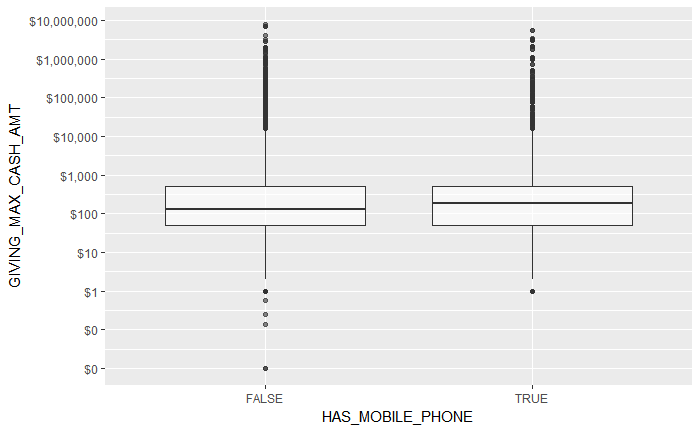

```r
boxplotter('HAS_MOBILE_PHONE')
```

Looks fine.

```r
summary(full.data$HAS_HOME_EMAIL)
```

```
FALSE  TRUE
40895 52332
```

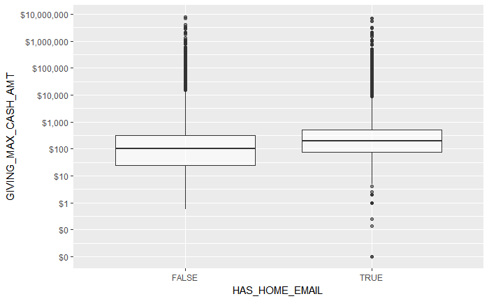

```r
boxplotter('HAS_HOME_EMAIL')
```

Looks fine.

```r
summary(full.data$HAS_BUS_EMAIL)
```

```
FALSE  TRUE
65546 27681
```

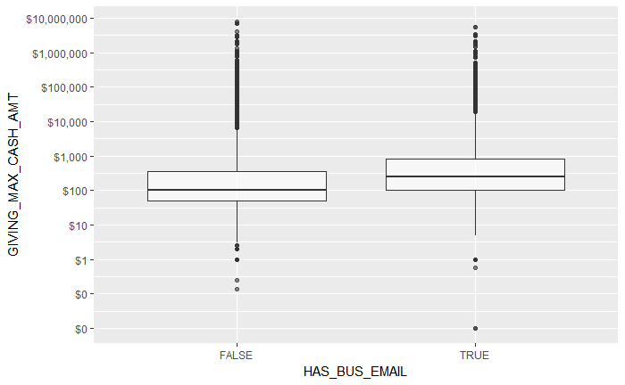

```r
boxplotter('HAS_BUS_EMAIL')
```

Looks fine.

```r
summary(full.data$EVALUATION_RATING)
```

```
                        A1 $100M+  A2 $50M - 99.9M A3 $25M - $49.9M A4 $10M - $24.9M
           83706               55               26               51              102
  A5 $5M - $9.9M   A6 $2M - $4.9M   A7 $1M - $1.9M B  $500K - $999K C  $250K - $499K
             172              337              552             1169             2434
D  $100K - $249K   E  $50K - $99K   F  $25K - $49K   G  $10K - $24K    H  Under $10K
            2604              683              786              475               75
```

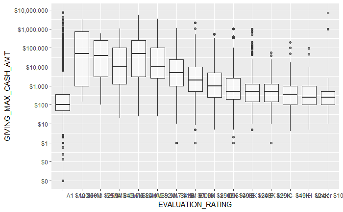

```r
boxplotter('EVALUATION_RATING')
```

Would likely combine all the $1M+ levels. Note that the evaluation rating process is causally associated with solicitations and thus gift size. **CAUTION - endogenous**

```r
summary(full.data$KSM_PROSPECT_ACTIVE)
```

```
FALSE  TRUE
85802  7425
```

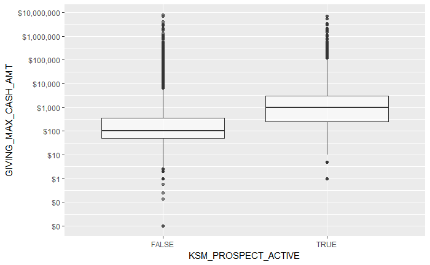

```r
boxplotter('KSM_PROSPECT_ACTIVE')
```

Looks fine.

```r
summary(full.data$KSM_PROSPECT_ANY)
```

```
FALSE  TRUE
83358  9869
```

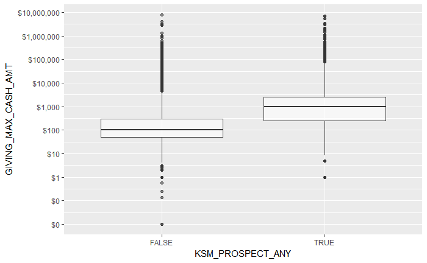

```r
boxplotter('KSM_PROSPECT_ANY')
```

Looks fine. **Consider making a new factor combining `KSM_PROSPECT_ACTIVE` and `KSM_PROSPECT_ANY`**

```r
# Derived variable
full.data <- full.data %>% mutate(
  KSM_PROSPECT = case_when(
    KSM_PROSPECT_ACTIVE == TRUE ~ 'Current'
    , KSM_PROSPECT_ANY == TRUE ~ 'Past'
    , TRUE ~ 'No') %>% factor()
)
summary(full.data$KSM_PROSPECT)
```

```
Current      No    Past
   7425   83358    2444
```

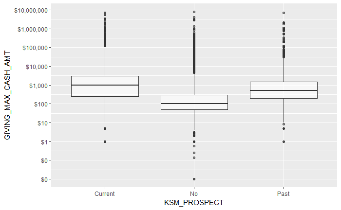

```r
boxplotter('KSM_PROSPECT')
```

Looks good.

```r
summary(full.data$GIVING_MAX_CASH_MO)
```

```
    1     2     3     4     5     6     7     8     9    10    11    12  NA's
 2575  2393  2924  3663  5064  5511  2523  4079  1546  2555  4067 10844 45483
```

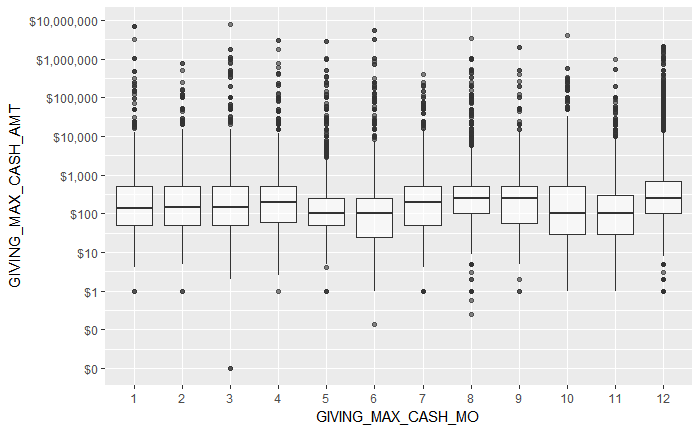

```r
boxplotter('GIVING_MAX_CASH_MO')
```

Looks good.